[figure not shown]

# Credit Card Fraud Detection

# - Pravin Nanasaheb Chavan

## Problem Statement:

#### With the growth of e-commerce websites, people and financial companies rely on online services to carry out their transactions that have led to an exponential increase in the credit card frauds. The design of an effective fraud detection system is necessary in order to reduce the losses incurred by the customers and financial companies. The Credit Card Fraud Detection Problem includes modeling past credit card transactions with the knowledge of the ones that turned out to be fraud. This model is then used to identify whether a new transaction is fraudulent or not. A good fraud detection system should be able to identify the fraud transaction accurately and should make the detection possible in real-time transactions. Mis-used (Supervised Learning) and Anomaly detection (Unsupervised Learning) systems bring normal transaction to be trained and use techniques to determine novel frauds. From a set of given data we have to design the machine learning algorithm which best fits the data and able to recognise the fraud transaction accurately.

## Steps

### The steps to develop the algorithm can be as follows:

1. Loading the Dataset
2. Data Visualization
3. Data Preprocessing
4. Training and Testing Algorithms
5. Result
6. Conclusion

## Before Starting Lets Import Some Useful Libraries

```python
import itertools
import numpy as np
import matplotlib.pyplot as plt
import pandas as pd
import numpy as np
import seaborn as sns
from sklearn import preprocessing
%matplotlib inline
```

## 1. Loading the Dataset

The csv file naming "creditcard" has been downloaded from "https://www.kaggle.com/mlg-ulb/creditcardfraud". The CSV file is uploaded to IBM watson studio in respective project folder and from their it has been loaded to notebook. It can be easily loded by clicking the options 'Insert to code' and then 'pandas DataFrame'.

```python
import types
import pandas as pd
from botocore.client import Config
import ibm_boto3

def __iter__(self): return 0

# @hidden_cell
# The following code accesses a file in your IBM Cloud Object Storage. It includes your credentials.
# You might want to remove those credentials before you share the notebook.
client_467ab304a08b4592a89735517a1edeb4 = ibm_boto3.client(service_name='s3',
    ibm_api_key_id='xZMX16jnde0WutXOPHOi1Np2wbrKuH0Ob3bkgrZMlqhR',
    ibm_auth_endpoint="https://iam.cloud.ibm.com/oidc/token",
    config=Config(signature_version='oauth'),
    endpoint_url='https://s3-api.us-geo.objectstorage.service.networklayer.com')

body = client_467ab304a08b4592a89735517a1edeb4.get_object(Bucket='creditcardfrauddetection-donotdelete-pr-ay7jwmpxw9os3x',Key='creditcard.csv')['Body']
# add missing __iter__ method, so pandas accepts body as file-like object
if not hasattr(body, "__iter__"): body.__iter__ = types.MethodType( __iter__, body )

data = pd.read_csv(body)
data.head()
```

|  | Time | V1 | V2 | V3 | V4 | V5 | V6 | V7 | V8 | V9 | ... | V21 | V22 | V23 | V24 | V25 | V26 | V27 | V28 | Amount | Class |
| --- | --- | --- | --- | --- | --- | --- | --- | --- | --- | --- | --- | --- | --- | --- | --- | --- | --- | --- | --- | --- | --- |
| 0 | 0.0 | -1.359807 | -0.072781 | 2.536347 | 1.378155 | -0.338321 | 0.462388 | 0.239599 | 0.098698 | 0.363787 | ... | -0.018307 | 0.277838 | -0.110474 | 0.066928 | 0.128539 | -0.189115 | 0.133558 | -0.021053 | 149.62 | 0 |
| 1 | 0.0 | 1.191857 | 0.266151 | 0.166480 | 0.448154 | 0.060018 | -0.082361 | -0.078803 | 0.085102 | -0.255425 | ... | -0.225775 | -0.638672 | 0.101288 | -0.339846 | 0.167170 | 0.125895 | -0.008983 | 0.014724 | 2.69 | 0 |
| 2 | 1.0 | -1.358354 | -1.340163 | 1.773209 | 0.379780 | -0.503198 | 1.800499 | 0.791461 | 0.247676 | -1.514654 | ... | 0.247998 | 0.771679 | 0.909412 | -0.689281 | -0.327642 | -0.139097 | -0.055353 | -0.059752 | 378.66 | 0 |
| 3 | 1.0 | -0.966272 | -0.185226 | 1.792993 | -0.863291 | -0.010309 | 1.247203 | 0.237609 | 0.377436 | -1.387024 | ... | -0.108300 | 0.005274 | -0.190321 | -1.175575 | 0.647376 | -0.221929 | 0.062723 | 0.061458 | 123.50 | 0 |
| 4 | 2.0 | -1.158233 | 0.877737 | 1.548718 | 0.403034 | -0.407193 | 0.095921 | 0.592941 | -0.270533 | 0.817739 | ... | -0.009431 | 0.798278 | -0.137458 | 0.141267 | -0.206010 | 0.502292 | 0.219422 | 0.215153 | 69.99 | 0 |

5 rows × 31 columns

## 2. Data Visualization

### 2.1 About Dataset

Understanding the data is important before going to develop an algorithm from it.

```python
data = data.sample(frac = 0.2, random_state = 1)
print( 'Data shape:', data.shape)
```

```
Data shape: (56961, 31)
```

```python
print(data.columns)
```

```
Index(['Time', 'V1', 'V2', 'V3', 'V4', 'V5', 'V6', 'V7', 'V8', 'V9', 'V10',
       'V11', 'V12', 'V13', 'V14', 'V15', 'V16', 'V17', 'V18', 'V19', 'V20',
       'V21', 'V22', 'V23', 'V24', 'V25', 'V26', 'V27', 'V28', 'Amount',
       'Class'],
      dtype='object')
```

So, we having 56961 rows of data having 31 column each.

### 2.2 Data Description

Let's find some details of each columns like mean, maximum, minimum, average, standard deviation, etc. Also plotting histogram of each column will help us to understand the data distribution.

```python
print(data.describe())
```

```
               Time            V1            V2            V3            V4  \
count   56961.00000  56961.000000  56961.000000  56961.000000  56961.000000
mean    94571.23811      0.007759     -0.007820      0.010548      0.004755
std     47566.88462      1.944402      1.654560      1.495860      1.415369
min         0.00000    -46.855047    -63.344698    -31.813586     -5.266509
25%     53809.00000     -0.915616     -0.607161     -0.883553     -0.843085
50%     84511.00000      0.033625      0.061363      0.185144     -0.012678
75%    139237.00000      1.318624      0.800511      1.031245      0.750016
max    172784.00000      2.411499     17.418649      4.069865     16.715537

                 V5            V6            V7            V8            V9  \
count  56961.000000  56961.000000  56961.000000  56961.000000  56961.000000
mean      -0.011918      0.002191     -0.011845      0.000873      0.007915
std        1.379057      1.329111      1.209897      1.160905      1.093541
min      -42.147898    -23.496714    -26.548144    -33.785407     -8.739670
25%       -0.707818     -0.765759     -0.563241     -0.206358     -0.632800
50%       -0.071228     -0.270147      0.030874      0.024519     -0.044122
75%        0.605042      0.403820      0.558736      0.327343      0.605625
max       34.099309     22.529298     36.677268     19.587773     10.370658

       ...           V21           V22           V23           V24  \
count  ...  56961.000000  56961.000000  56961.000000  56961.000000
mean   ...      0.002932      0.003058     -0.001127     -0.001869
std    ...      0.723614      0.723845      0.654303      0.603150
min    ...    -16.640785    -10.933144    -36.666000     -2.836627
25%    ...     -0.227125     -0.541228     -0.162431     -0.356802
50%    ...     -0.029706      0.010522     -0.010926      0.038833
75%    ...      0.186236      0.531158      0.148271      0.434270
max    ...     22.588989      6.090514     18.946734      3.962197

                V25           V26           V27           V28        Amount  \
count  56961.000000  56961.000000  56961.000000  56961.000000  56961.000000
mean       0.000662      0.002157      0.000632     -0.002841     88.750996
std        0.519287      0.481474      0.393477      0.302685    254.652038
min       -7.025783     -2.534330     -8.260909     -9.617915      0.000000
25%       -0.316805     -0.324992     -0.071111     -0.053391      5.950000
50%        0.017169     -0.049862      0.001250      0.010776     22.160000
75%        0.350835      0.243869      0.089448      0.076211     77.900000
max        5.541598      3.155327     11.135740     15.373170  19656.530000

              Class
count  56961.000000
mean       0.001527
std        0.039052
min        0.000000
25%        0.000000
50%        0.000000
75%        0.000000
max        1.000000

[8 rows x 31 columns]
```

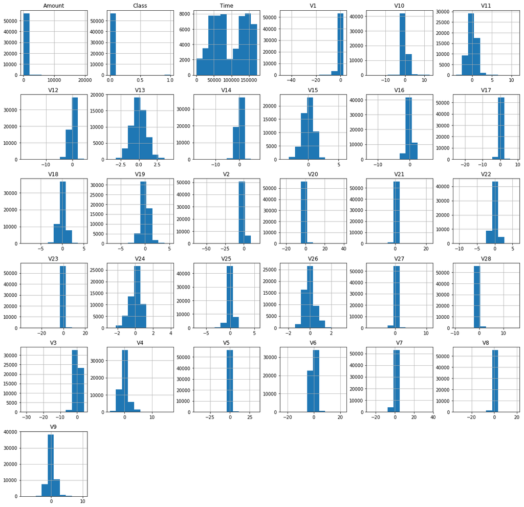

```python
# Plotting histogram of each parameter

data.hist(figsize = (20,20))
plt.show()
```

### 2.3 Understanding the Data

As in credit card fraud detection we should have plenty of valid cases with respective fraud cases. So developing algorithm should understand the relationship between the columns more precisely. Let's understand the relationship with correlation matrix.

```python
# Determine total number fraud and valid cases

Fraud = data[data['Class'] == 1]
Valid = data[data['Class'] == 0]
print ('Number of Fraud cases: {}'.format(len(Fraud)))
print ('Number of Valid cases: {}'.format(len(Valid)))

Outlier_Fraction = len(Fraud)/float(len(Valid))
print ('Outlier Fraction', Outlier_Fraction)
```

```
Number of Fraud cases: 87
Number of Valid cases: 56874
Outlier Fraction 0.0015296972254457222
```

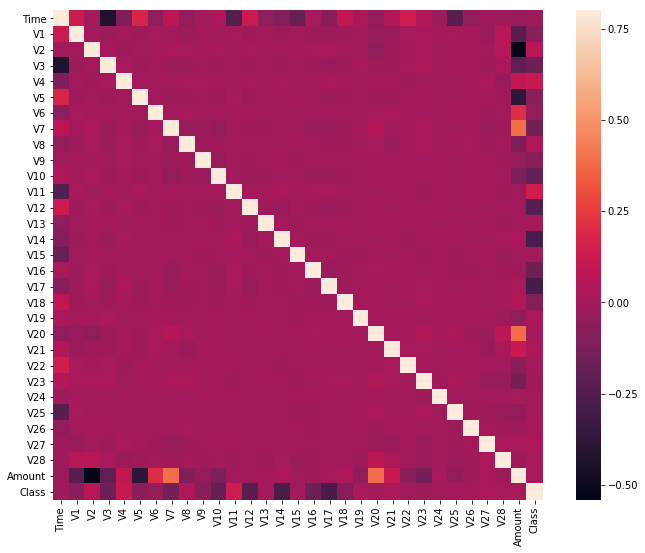

```python
# Correlation Matrix

corrmat = data.corr()
fig = plt.figure(figsize = (12,9))

sns.heatmap(corrmat, vmax = 0.8, square = True)
plt.show()
```

## 3. Data Preprocessing

### 3.1 Setting variables

As it is a supervised and unsupervised learning problem, we should set two variables namely; X: for parameters to set, Y: for prediction to verify.

```python
X = data[['Time', 'V1', 'V2', 'V3', 'V4', 'V5', 'V6', 'V7', 'V8', 'V9', 'V10',
       'V11', 'V12', 'V13', 'V14', 'V15', 'V16', 'V17', 'V18', 'V19', 'V20',
       'V21', 'V22', 'V23', 'V24', 'V25', 'V26', 'V27', 'V28', 'Amount']]
Y = data[['Class']]
print ('Size of X:', X.shape)
print ('Size of Y:', Y.shape)
```

```
Size of X: (56961, 30)
Size of Y: (56961, 1)
```

### 3.2 Normalising Data

Also from the Data Description we can see that the range of parameters are varries with different columns. So we need to normalised the data so every parameter must get approx equal weightage at the starting of training algorithm.

```python
X = preprocessing.StandardScaler().fit(X).transform(X)
X [0:2]
```

```
array([[ 0.53263914, -0.31859464, -0.46047996, -0.10716813, -0.16224314,
         1.4796443 , -1.52138927,  0.25154142, -0.4512843 ,  0.32057048,
         0.06360386, -0.83475431,  0.55572809,  0.61706154, -0.11039761,
        -0.66619357, -0.33200716, -0.73215432, -1.07900467, -0.24519171,
        -0.26048814, -0.10798607,  0.05868386,  0.58362784,  0.04196186,
        -4.27772485, -0.42225416,  0.16740425,  0.74011768, -0.34149249],
       [-0.34123279, -0.42298225,  0.80205636,  0.88168557,  0.0159093 ,
        -0.19792869, -0.49369923,  0.27556034,  0.3747984 , -0.65129588,
        -0.5650161 ,  0.09916382,  0.72002972,  0.78005994,  0.37171009,
         1.03882963, -0.12009189,  0.14554589, -1.15460362, -0.58309297,
        -0.01436232, -0.18179792, -0.51340666,  0.14028202,  0.668191  ,
        -0.50395652,  0.16296617,  0.41119678,  0.20581665, -0.34074637]])
```

### 3.3 Train-Test Split

As we are going to develop the algorithm, the algorithm should be checked/tested for its accuracy on the unknown data (the data which is not used for training the algorithm in case of supervised learning). So we use about 90% data for training the algorithm and 10% for testing the data.

```python
from sklearn.model_selection import train_test_split
X_train, X_test, Y_train, Y_test = train_test_split(X, Y, test_size = 0.10, random_state = 4)
print ('Train set:', X_train.shape,  Y_train.shape)
print ('Test set:', X_test.shape,  Y_test.shape)
```

```
Train set: (51264, 30) (51264, 1)
Test set: (5697, 30) (5697, 1)
```

## 4. Training and Testing the Algorithm

For training and testing algorithm we will import some libraries and some important testing metrics first.

```python
from sklearn.metrics import classification_report, accuracy_score, f1_score
from sklearn.neighbors import LocalOutlierFactor
from sklearn.ensemble import IsolationForest
from sklearn.neighbors import KNeighborsClassifier
from sklearn import svm
from sklearn.linear_model import LogisticRegression
```

## * Algorithms

We use following different types of algorithms which will be trained on same set of data and test for same parameters:

#### Supervised Learning

- K-Nearest Neighbors
- Support Vector Machine
- Logistic Regression

#### Unsupervised Learning

- Isolation Tree (Forest)
- Local Outlier Factor

### 4.1 K-Nearest Neighbors (KNN)

In KNN we first find out the value of K which gives highest efficiency. Then use same value of K for finding the other metrics.

```python
Ks=10
mean_acc = np.zeros ((Ks-1))
for n in range (1,Ks):
    neigh = KNeighborsClassifier (n_neighbors = n).fit(X_train,Y_train)
    Y_hat = neigh.predict(X_test)
    mean_acc[n-1] = accuracy_score(Y_test, Y_hat)

print("The best K is", mean_acc.argmax()+1, 'having maximum accuracy of', mean_acc.max())
```

```
The best K is 3 having maximum accuracy of 0.9991223450939091
```

```python
knn = KNeighborsClassifier (n_neighbors = 3).fit(X_train,Y_train)
Y_KNN = knn.predict(X_test)
print('Accuracy score: ',accuracy_score(Y_KNN, Y_test))
print(classification_report(Y_KNN, Y_test))
```

```
Accuracy score:  0.9991223450939091
              precision    recall  f1-score   support

           0       1.00      1.00      1.00      5687
           1       0.69      0.90      0.78        10

   micro avg       1.00      1.00      1.00      5697
   macro avg       0.85      0.95      0.89      5697
weighted avg       1.00      1.00      1.00      5697
```

### 4.2 Support Vector Machine

```python
clf = svm.SVC (kernel = 'rbf', gamma = 'auto')
clf.fit(X_train, Y_train)
Y_hat = clf.predict(X_test)
print('Accuracy score: ',accuracy_score(Y_hat, Y_test))
print(classification_report(Y_hat, Y_test))
```

```
Accuracy score:  0.9984202211690363
              precision    recall  f1-score   support

           0       1.00      1.00      1.00      5691
           1       0.38      0.83      0.53         6

   micro avg       1.00      1.00      1.00      5697
   macro avg       0.69      0.92      0.76      5697
weighted avg       1.00      1.00      1.00      5697
```

### 4.3 Logistic Regression

```python
LR = LogisticRegression (C = 0.01, solver = 'saga')
LR.fit(X_train, Y_train)
Y_LR = LR.predict(X_test)
print('Accuracy score: ',accuracy_score(Y_LR, Y_test))
print(classification_report(Y_LR, Y_test))
```

```
Accuracy score:  0.9984202211690363
              precision    recall  f1-score   support

           0       1.00      1.00      1.00      5687
           1       0.54      0.70      0.61        10

   micro avg       1.00      1.00      1.00      5697
   macro avg       0.77      0.85      0.80      5697
weighted avg       1.00      1.00      1.00      5697
```

### 4.4 Isolation Tree (Forest)

```python
IF = IsolationForest (max_samples = len(X_train), contamination = Outlier_Fraction, random_state = 1)
IF.fit(X_train)
score_prediction = IF.decision_function(X_train)
Y_IF = IF.predict(X_train)

Y_IF[Y_IF == 1] = 0
Y_IF[Y_IF == -1] = 1

print('Accuracy score: ',accuracy_score(Y_IF, Y_train))
print(classification_report(Y_IF, Y_train))
```

```
Accuracy score:  0.9978347378277154
              precision    recall  f1-score   support

           0       1.00      1.00      1.00     51185
           1       0.28      0.27      0.27        79

   micro avg       1.00      1.00      1.00     51264
   macro avg       0.64      0.63      0.64     51264
weighted avg       1.00      1.00      1.00     51264
```

### 4.5 Local Outlier Factor

```python
LOF = LocalOutlierFactor (n_neighbors = 3, contamination = Outlier_Fraction)
Y_LOF = LOF.fit_predict(X_train)
score_prediction = LOF.negative_outlier_factor_

Y_LOF[Y_LOF == 1] = 0
Y_LOF[Y_LOF == -1] = 1

print('Accuracy score: ',accuracy_score(Y_LOF, Y_train))
print(classification_report(Y_LOF, Y_train))
```

```
Accuracy score:  0.9970544631710362
              precision    recall  f1-score   support

           0       1.00      1.00      1.00     51187
           1       0.00      0.00      0.00        77

   micro avg       1.00      1.00      1.00     51264
   macro avg       0.50      0.50      0.50     51264
weighted avg       1.00      1.00      1.00     51264
```

## 5. Result

```python
Accuracy_score = [accuracy_score(Y_KNN, Y_test),
          accuracy_score(Y_hat, Y_test),
          accuracy_score(Y_LR, Y_test),
          accuracy_score(Y_IF, Y_train),
          accuracy_score(Y_LOF, Y_train)]
Recall_1 = [0.90, 0.83, 0.70, 0.28, 0 ]
Precision_1 = [0.69, 0.38, 0.54, 0.27, 0 ]
f1_score = [f1_score(Y_KNN, Y_test),
          f1_score(Y_hat, Y_test),
          f1_score(Y_LR, Y_test),
          f1_score(Y_IF, Y_train),
          f1_score(Y_LOF, Y_train)]

df = {'Algorithm': ['K-Nearest Neighbor','Support Vector Machine', 'Logistic Regression','Isolation Forest','Local Outlier Detector'], \
     'Accuracy Score': Accuracy_score, 'Recall': Recall_1, 'Precision':Precision_1, 'F1 score':f1_score}

Report = pd.DataFrame(data=df, columns=['Algorithm', 'Accuracy Score', 'Recall','Precision', 'F1 score'], index=None)
Report
```

[output not shown]

## 6. Conclusion

### Supervised Learning Algorithms

From the above table we can see that both Support Vector Machine and Logistic Regression same accuracy where K-Nearest Neighbor having highest efficiency. The difference in efficiency is also small so we need to check other metrics. All of supervised learning algorithms are varring in Precision and Recall. In our case, predicting the valid transaction which is actually a fraud (False Negative) can not be tolerate. So our algorithm should have minimum False Negative cases. Similarly predicting the fraud transaction which is actually a fraud (True Positive) is more important than predicting fraud transaction for valid transaction (False Positive). Although we want our algorithm should give minimum False Positive. High Precision implies low False Positive rate and high Recall implies low False Negative rate. As per our conditions our algorithm should have low False Negative rate i.e High Recall.

#### Accuracy score, Recall, Precision, F1 score indicating that K-Nearest Neighbors is the best algorithm (of all tested) for predicting credit card fraud trasaction in case of supervised learning.

### Unsupervised Learning Algorithms

In case of unsupervised learning Isolation Forest has higher accuracy, Precision and Recall. So we can say that Isolation Forest is the goad algorithm for our task.